# Chapter 5: Time Value of Money

## How to get paid? FV

You have agreed to work for Justin’s Cupcakes for the summer, 3 months. I offer to pay you 6K at the end of the summer or $1.8K at the end of every month. The rate is 3%. Which do you prefer? (Find the FV of each option.)

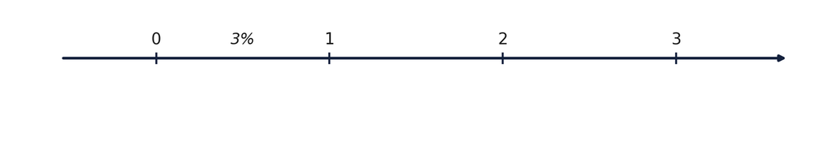

## How to get paid? FV

You have agreed to work for Justin’s Cupcakes for the summer, 3 months. I offer to pay you 6K at the end of the summer or $1.8K at the end of every month. The rate is 3%. Which do you prefer? (Find the FV of each option.)

Option 1

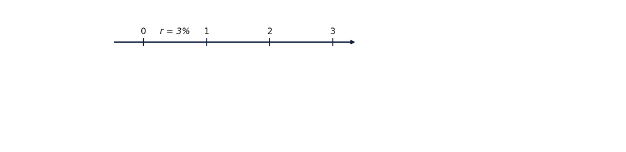

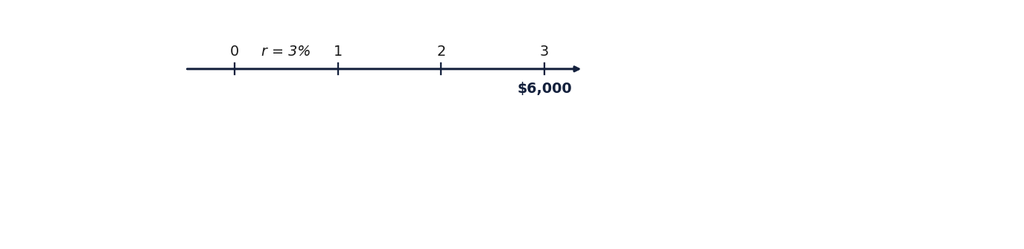

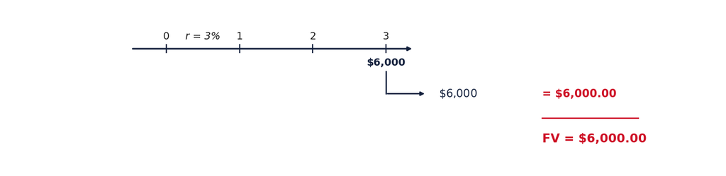

## How to get paid? FV

You have agreed to work for Justin’s Cupcakes for the summer, 3 months. I offer to pay you 6K at the end of the summer or $1.8K at the end of every month. The rate is 3%. Which do you prefer? (Find the FV of each option.)

Option 2

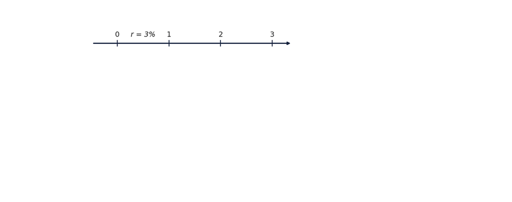

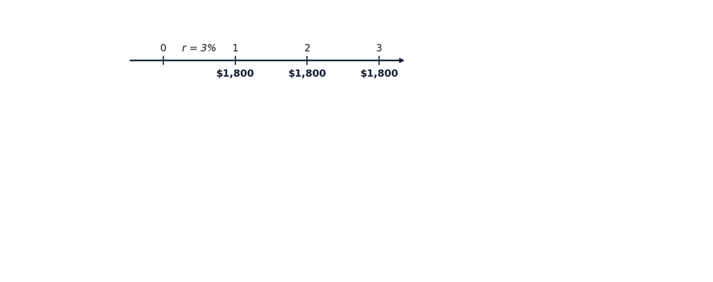

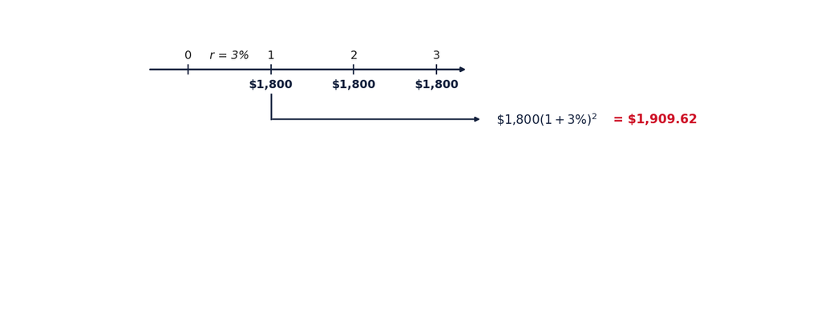

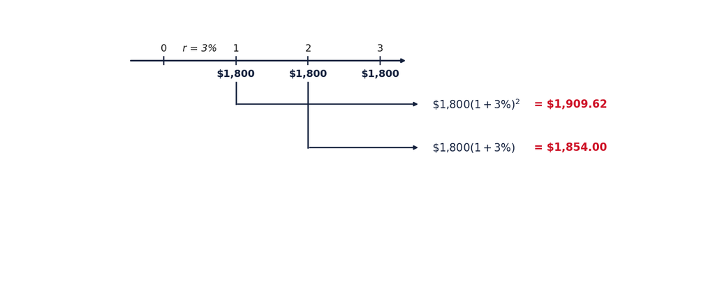

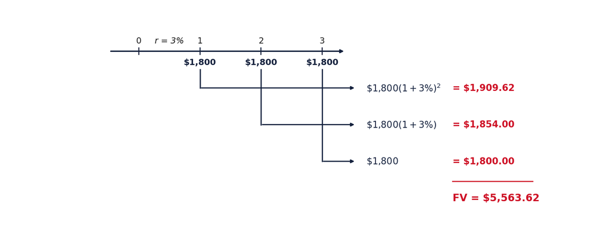

## Have a good day!

- Read Ch 5
- Get your homework turned in Sunday

## Upcoming Dates

Upcoming class dates and deadlines

| Date | Topic | Due / Notes |
| --- | --- | --- |
| Fri Sep 4 | Last day to register or add classes | DEADLINE |
| Sun Sep 6 | MindTap Ch 1, 3, 4 | HW DUE |
| Tue Sep 8 | Chapter 5: Time Value of Money | - |
| Thu Sep 10 | Chapter 5: Time Value of Money | - |

**Office:** 325 Holman Hall · **Office hours:** T TH 10:50A-12:20P · jjmohr1@olemiss.edu